# Bigmart Sales 회귀 분석

```python
import numpy as np
import pandas as pd
import matplotlib.pyplot as plt
import seaborn as sns
```

### 1. 데이터 로딩 및 결측치 확인

```python
df = pd.read_csv('Bigmart.csv')
df.head()
```

|  | Item_Identifier | Item_Weight | Item_Fat_Content | Item_Visibility | Item_Type | Item_MRP | Outlet_Identifier | Outlet_Establishment_Year | Outlet_Size | Outlet_Location_Type | Outlet_Type | Item_Outlet_Sales |
| --- | --- | --- | --- | --- | --- | --- | --- | --- | --- | --- | --- | --- |
| 0 | FDA15 | 9.30 | Low Fat | 0.016047 | Dairy | 249.8092 | OUT049 | 1999 | Medium | Tier 1 | Supermarket Type1 | 3735.1380 |
| 1 | DRC01 | 5.92 | Regular | 0.019278 | Soft Drinks | 48.2692 | OUT018 | 2009 | Medium | Tier 3 | Supermarket Type2 | 443.4228 |
| 2 | FDN15 | 17.50 | Low Fat | 0.016760 | Meat | 141.6180 | OUT049 | 1999 | Medium | Tier 1 | Supermarket Type1 | 2097.2700 |
| 3 | FDX07 | 19.20 | Regular | 0.000000 | Fruits and Vegetables | 182.0950 | OUT010 | 1998 | NaN | Tier 3 | Grocery Store | 732.3800 |
| 4 | NCD19 | 8.93 | Low Fat | 0.000000 | Household | 53.8614 | OUT013 | 1987 | High | Tier 3 | Supermarket Type1 | 994.7052 |

```python
df.isna().sum()
```

```
Item_Identifier                 0
Item_Weight                  1463
Item_Fat_Content                0
Item_Visibility                 0
Item_Type                       0
Item_MRP                        0
Outlet_Identifier               0
Outlet_Establishment_Year       0
Outlet_Size                  2410
Outlet_Location_Type            0
Outlet_Type                     0
Item_Outlet_Sales               0
dtype: int64
```

### 2. 결측값 처리해주기

- Item_Weight의 경우 결측치에 이전 값을 대입

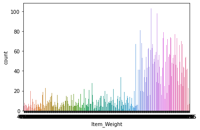

```python
sns.countplot(x = 'Item_Weight', data = df)
plt.show()
```

[figure not shown]

```python
df['Item_Weight'].fillna(method = 'pad', inplace=True)

sns.countplot(x = 'Item_Weight', data = df)
plt.show()
```

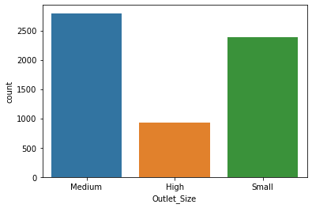

```python
sns.countplot(x = 'Outlet_Size', data = df)
plt.show()
```

- Outlet_Size의 경우에도 이전 값을 대입

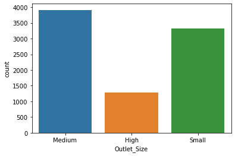

```python
df['Outlet_Size'].fillna(method = 'pad', inplace=True)

sns.countplot(x = 'Outlet_Size', data = df)
plt.show()
```

```python
df.isna().sum()
```

```
Item_Identifier              0
Item_Weight                  0
Item_Fat_Content             0
Item_Visibility              0
Item_Type                    0
Item_MRP                     0
Outlet_Identifier            0
Outlet_Establishment_Year    0
Outlet_Size                  0
Outlet_Location_Type         0
Outlet_Type                  0
Item_Outlet_Sales            0
dtype: int64
```

### 2. 데이터 전처리

```python
df.head()
```

|  | Item_Identifier | Item_Weight | Item_Fat_Content | Item_Visibility | Item_Type | Item_MRP | Outlet_Identifier | Outlet_Establishment_Year | Outlet_Size | Outlet_Location_Type | Outlet_Type | Item_Outlet_Sales |
| --- | --- | --- | --- | --- | --- | --- | --- | --- | --- | --- | --- | --- |
| 0 | FDA15 | 9.30 | Low Fat | 0.016047 | Dairy | 249.8092 | OUT049 | 1999 | Medium | Tier 1 | Supermarket Type1 | 3735.1380 |
| 1 | DRC01 | 5.92 | Regular | 0.019278 | Soft Drinks | 48.2692 | OUT018 | 2009 | Medium | Tier 3 | Supermarket Type2 | 443.4228 |
| 2 | FDN15 | 17.50 | Low Fat | 0.016760 | Meat | 141.6180 | OUT049 | 1999 | Medium | Tier 1 | Supermarket Type1 | 2097.2700 |
| 3 | FDX07 | 19.20 | Regular | 0.000000 | Fruits and Vegetables | 182.0950 | OUT010 | 1998 | Medium | Tier 3 | Grocery Store | 732.3800 |
| 4 | NCD19 | 8.93 | Low Fat | 0.000000 | Household | 53.8614 | OUT013 | 1987 | High | Tier 3 | Supermarket Type1 | 994.7052 |

- 카테고리형 변수들의 분포 확인

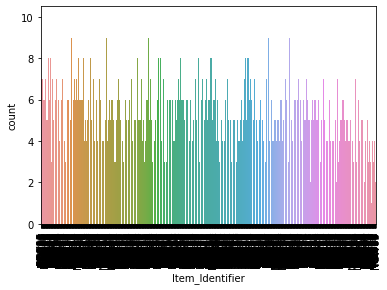

```python
sns.countplot(x = 'Item_Identifier', data = df)
plt.xticks(rotation = 90)
plt.show()
```

Item_Identifier의 경우 카테고리로 되어 있지만 카테고리의 갯수가 매우 많음을 확인할 수 있다

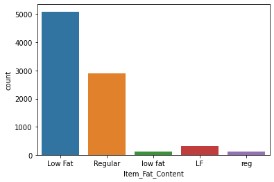

```python
sns.countplot(x = 'Item_Fat_Content', data = df)
plt.show()
```

Item_Fat_Content의 경우 명칭을 통일할 필요가 있다

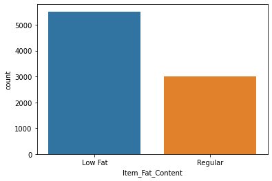

```python
mask1 = df['Item_Fat_Content'].isin(['low fat', 'LF'])
mask2 = df['Item_Fat_Content'].isin(['reg'])

df.loc[mask1, 'Item_Fat_Content'] = 'Low Fat'
df.loc[mask2, 'Item_Fat_Content'] = 'Regular'

sns.countplot(x = 'Item_Fat_Content', data = df)
plt.show()
```

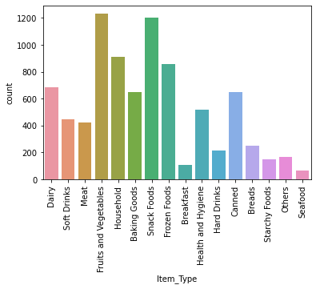

```python
sns.countplot(x = 'Item_Type', data = df)
plt.xticks(rotation = 90)
plt.show()
```

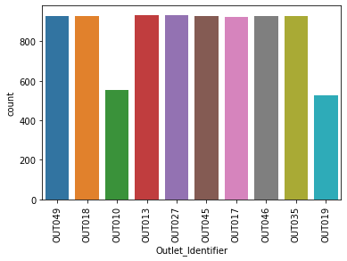

```python
sns.countplot(x = 'Outlet_Identifier', data = df)
plt.xticks(rotation = 90)
plt.show()
```

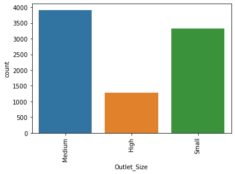

```python
sns.countplot(x = 'Outlet_Size', data = df)
plt.xticks(rotation = 90)
plt.show()
```

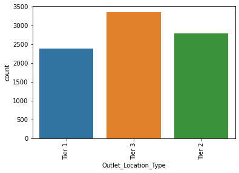

```python
sns.countplot(x = 'Outlet_Location_Type', data = df)
plt.xticks(rotation = 90)
plt.show()
```

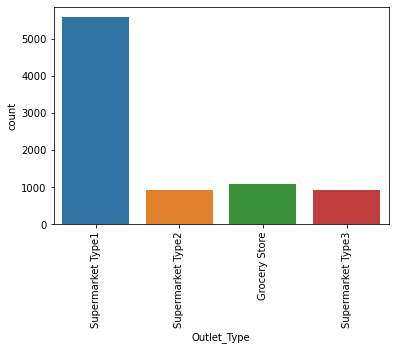

```python
sns.countplot(x = 'Outlet_Type', data = df)
plt.xticks(rotation = 90)
plt.show()
```

- 레이블 인코딩 수행

```python
from sklearn.preprocessing import LabelEncoder

le = LabelEncoder()

for column in [df.columns[0], df.columns[2], df.columns[4], df.columns[6], df.columns[8], df.columns[9], df.columns[10]]:
    df[column] = le.fit_transform(df[column])

df.head()
```

|  | Item_Identifier | Item_Weight | Item_Fat_Content | Item_Visibility | Item_Type | Item_MRP | Outlet_Identifier | Outlet_Establishment_Year | Outlet_Size | Outlet_Location_Type | Outlet_Type | Item_Outlet_Sales |
| --- | --- | --- | --- | --- | --- | --- | --- | --- | --- | --- | --- | --- |
| 0 | 156 | 9.30 | 0 | 0.016047 | 4 | 249.8092 | 9 | 1999 | 1 | 0 | 1 | 3735.1380 |
| 1 | 8 | 5.92 | 1 | 0.019278 | 14 | 48.2692 | 3 | 2009 | 1 | 2 | 2 | 443.4228 |
| 2 | 662 | 17.50 | 0 | 0.016760 | 10 | 141.6180 | 9 | 1999 | 1 | 0 | 1 | 2097.2700 |
| 3 | 1121 | 19.20 | 1 | 0.000000 | 6 | 182.0950 | 0 | 1998 | 1 | 2 | 0 | 732.3800 |
| 4 | 1297 | 8.93 | 0 | 0.000000 | 9 | 53.8614 | 1 | 1987 | 0 | 2 | 1 | 994.7052 |

### 3. 변수간 상관관계 분석

- heatmap을 통한 변수간 상관관계 분석

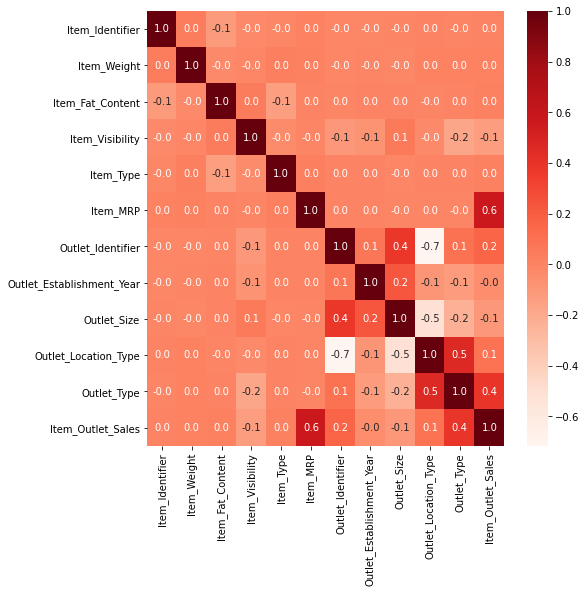

```python
plt.figure(figsize=(8, 8))
sns.heatmap(df.corr(), cmap = 'Reds', annot = True, fmt = '.1f')
plt.show()
```

target 변수(Item_Outlet_Sales)와 직접적인 상관관계를 보이는 것은 Item_MRP(최종 소매가격)과 Outlet_Type정도인 것으로 보인다

주제1) Item_MRP와 Item_Outlet_sales의 상관관계 분석

```python
from sklearn.linear_model import LinearRegression

X_mrp_train, X_mrp_test, y_mrp_train, y_mrp_test = train_test_split(
    df['Item_MRP'].values.reshape(-1, 1), df['Item_Outlet_Sales'].values, test_size = 0.1, random_state = 2022
)

lr_mrp = LinearRegression()
lr_mrp.fit(X_mrp_train, y_mrp_train)
lr_mrp.score(X_mrp_test, y_mrp_test)
```

```
0.3410131725198874
```

```python
lr_mrp.coef_, lr_mrp.intercept_
```

[output not shown]

```python
min(df['Item_MRP']), max(df['Item_MRP'])
```

```
(31.29, 266.8884)
```

```python
x_mrp = np.array([31, 267])
y_mrp = x_mrp * lr_mrp.coef_ + lr_mrp.intercept_
y_mrp
```

```
array([ 470.56858677, 4141.08214107])
```

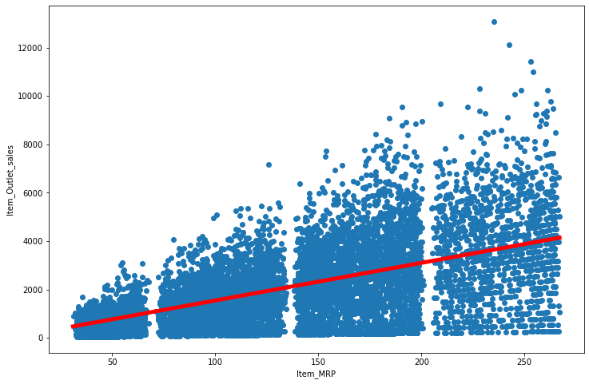

```python
plt.figure(figsize = (12, 8))
plt.plot(x_mrp, y_mrp, 'r-', lw = 5)
plt.scatter(df['Item_MRP'], df['Item_Outlet_Sales'])
plt.xlabel('Item_MRP')
plt.ylabel('Item_Outlet_sales')
plt.show()
```

소결1) 빅마트에서 파는 상당수의 제품들은 식료품 등 생활 필수품인 경우가 많다. 그 결과 가격이 높더라도 총매출이 증가하는 현상을 보이는 것으로 해석된다.

주제2) Outlet_type이 총매출과 상관성을 보이는 것은 흥미롭다. 따라서 이에 대해 분석해보기로 한다

단순 선형회귀에서는 label encoding을 사용할 경우 정수형으로 변환됨으로 인하여 문제가 발생할 수 있다. 따라서 OntHotEncoding 방식을 사용하여 상관성을 분석해보기로 한다.

```python
df2 = pd.read_csv('Bigmart.csv')
df2[['Outlet_Type']].head()
```

|  | Outlet_Type |
| --- | --- |
| 0 | Supermarket Type1 |
| 1 | Supermarket Type2 |
| 2 | Supermarket Type1 |
| 3 | Grocery Store |
| 4 | Supermarket Type1 |

```python
# le1 = LabelEncoder()
# le11 = le1.fit_transform(df['Outlet_Type']).reshape(-1, 1)

# from sklearn.preprocessing import OneHotEncoder

# oh = OneHotEncoder()
# oh_type = oh.fit_transform(le11)

df_oh = pd.DataFrame(df2['Outlet_Type'])
df_ohe = pd.get_dummies(df_oh)
df_ohe.columns = ['Grocery', 'Super1', 'Super2', 'Super3']
df_ohe['Item_Outlet_Sales'] = df['Item_Outlet_Sales']
df_ohe
```

|  | Grocery | Super1 | Super2 | Super3 | Item_Outlet_Sales |
| --- | --- | --- | --- | --- | --- |
| 0 | 0 | 1 | 0 | 0 | 3735.1380 |
| 1 | 0 | 0 | 1 | 0 | 443.4228 |
| 2 | 0 | 1 | 0 | 0 | 2097.2700 |
| 3 | 1 | 0 | 0 | 0 | 732.3800 |
| 4 | 0 | 1 | 0 | 0 | 994.7052 |
| ... | ... | ... | ... | ... | ... |
| 8518 | 0 | 1 | 0 | 0 | 2778.3834 |
| 8519 | 0 | 1 | 0 | 0 | 549.2850 |
| 8520 | 0 | 1 | 0 | 0 | 1193.1136 |
| 8521 | 0 | 0 | 1 | 0 | 1845.5976 |
| 8522 | 0 | 1 | 0 | 0 | 765.6700 |

8523 rows × 5 columns

```python
X_type = df_ohe.iloc[:, 1:-1].values
y_type = df_ohe.iloc[:, -1]
```

```python
X_type_train, X_type_test, y_type_train, y_type_test = train_test_split(
    X_type, y_type, test_size = 0.1, random_state = 2022
)
```

```python
lr_type = LinearRegression()
lr_type.fit(X_type_train, y_type_train)
```

```
LinearRegression()
```

```python
lr_type.coef_, lr_type.intercept_, lr_type.score(X_type_test, y_type_test)
```

```
(array([1983.09191189, 1630.98898923, 3328.033009  ]),
 333.4762122324198,
 0.23634751168268442)
```

회귀식은 아래와 같다

- Outlet_sales = 333.48 + 1983.10 *Super1 + 1630.99* Super2 + 3328.03 * Super3
- Grocery인 경우 : Super1 = 0, Super2 = 0, Super3 = 0
- Super1인 경우 : Super1 = 1, Super2 = 0, Super3 = 0
- Super2인 경우 : Super1 = 0, Super2 = 1, Super3 = 0
- Super3인 경우 : Super1 = 0, Super2 = 0, Super3 = 1

결론2) Grocery인 경우보다 Supermarket에서 파는 경우가 매출액이 더 높으며 그 중에서도 Supermarket 3에서 파는 경우가 매출액이 더 높다

### 4. 훈련/테스트 데이터셋 분리

- 변수간 상관관계를 분석한 바, 이제 실제 머신러닝 훈련, 평가를 수행한다

```python
df.head()
```

|  | Item_Identifier | Item_Weight | Item_Fat_Content | Item_Visibility | Item_Type | Item_MRP | Outlet_Identifier | Outlet_Establishment_Year | Outlet_Size | Outlet_Location_Type | Outlet_Type | Item_Outlet_Sales |
| --- | --- | --- | --- | --- | --- | --- | --- | --- | --- | --- | --- | --- |
| 0 | 156 | 9.30 | 0 | 0.016047 | 4 | 249.8092 | 9 | 1999 | 1 | 0 | 1 | 3735.1380 |
| 1 | 8 | 5.92 | 1 | 0.019278 | 14 | 48.2692 | 3 | 2009 | 1 | 2 | 2 | 443.4228 |
| 2 | 662 | 17.50 | 0 | 0.016760 | 10 | 141.6180 | 9 | 1999 | 1 | 0 | 1 | 2097.2700 |
| 3 | 1121 | 19.20 | 1 | 0.000000 | 6 | 182.0950 | 0 | 1998 | 1 | 2 | 0 | 732.3800 |
| 4 | 1297 | 8.93 | 0 | 0.000000 | 9 | 53.8614 | 1 | 1987 | 0 | 2 | 1 | 994.7052 |

```python
X = df.iloc[:, :-1]
y = df.iloc[:, -1]
```

```python
from sklearn.model_selection import train_test_split

X_train, X_test, y_train, y_test = train_test_split(
    X, y, test_size=0.1, random_state= 2022
)
```

### 5. 데이터 학습/ 훈련 평가

a) 선형 회귀를 이용한 모델 평가

```python
from sklearn.linear_model import LinearRegression

lr = LinearRegression()
lr.fit(X_train, y_train)
pred_lr = lr.predict(X_test)
lr.score(X_test, y_test)
```

```
0.513181792287849
```

```python
from sklearn.metrics import mean_squared_error

mse_lr = mean_squared_error(y_test, pred_lr)
mse_lr
```

```
1409728.7494892639
```

b) Random Forest 회귀를 이용한 모델 평가

```python
from sklearn.ensemble import RandomForestRegressor

rfr = RandomForestRegressor(random_state= 2022)
rfr.fit(X_train, y_train)
pred_rf = rfr.predict(X_test)
mse_rf = mean_squared_error(y_test, pred_rf)

rfr.score(X_test, y_test), mse_rf
```

```
(0.5542190180009734, 1290893.1020738774)
```

c) XGBoost 회귀를 이용한 모델 평가

```python
from xgboost import XGBRegressor

xgb = XGBRegressor(random_state= 2022)
xgb.fit(X_train, y_train)
pred_xg = xgb.predict(X_test)
mse_xg = mean_squared_error(y_test, pred_xg)

xgb.score(X_test, y_test), mse_xg
```

```
(0.48950851226850767, 1478281.8621487399)
```

### 6. 모델간 성과 비교

```python
df_score = pd.DataFrame({
    'y_test' : y_test, 'pred_lr' : pred_lr, 'pred_rf' : pred_rf, 'pred_xg' : pred_xg
})
df_score.head(10)
```

|  | y_test | pred_lr | pred_rf | pred_xg |
| --- | --- | --- | --- | --- |
| 4714 | 2508.7344 | 3512.703403 | 4166.403292 | 4733.476562 |
| 1137 | 1966.7732 | 1770.216904 | 2186.800126 | 2071.226562 |
| 2590 | 842.2370 | 1139.481308 | 456.905250 | 378.638123 |
| 7387 | 657.8104 | 1440.664458 | 329.544368 | -36.205967 |
| 1822 | 1404.8380 | 2207.716302 | 1997.979246 | 1983.133667 |
| 8264 | 3705.1770 | 2548.302376 | 3929.651470 | 3607.525879 |
| 3877 | 1777.6860 | 2434.875947 | 1736.559534 | 1568.068237 |
| 2738 | 1861.5768 | 2093.949704 | 2671.742214 | 2440.650879 |
| 6734 | 539.2980 | 646.328534 | 1710.633282 | 1109.659058 |
| 5194 | 3946.8624 | 4070.860797 | 4213.961386 | 4140.517090 |

```python
print(f'선형회귀 score :{lr.score(X_test, y_test)}, Random Forest score : {rfr.score(X_test, y_test)}, XGBoost score : {xgb.score(X_test, y_test)}')
print(f'선형회귀 mse :{mse_lr}, Random Forest mse : {mse_rf}, XGBoost mse : {mse_xg}')
```

```
선형회귀 score :0.513181792287849, Random Forest score : 0.5542190180009734, XGBoost score : 0.48950851226850767
선형회귀 mse :1409728.7494892639, Random Forest mse : 1290893.1020738774, XGBoost mse : 1478281.8621487399
```

여러 개의 모델 중 Random Forest 모델이 가장 나은 예측 성능을 보이는 것으로 보인다

### 추가) Item_Weight의 결측치를 평균으로 처리하고 Outlet_Size의 결측치를 최빈값으로 처리할 경우

### 1. 데이터 로딩 및 모듈 import

```python
import numpy as np
import pandas as pd
import matplotlib.pyplot as plt
import seaborn as sns
```

```python
df1 = pd.read_csv('Bigmart.csv')
df1.head(8)
```

|  | Item_Identifier | Item_Weight | Item_Fat_Content | Item_Visibility | Item_Type | Item_MRP | Outlet_Identifier | Outlet_Establishment_Year | Outlet_Size | Outlet_Location_Type | Outlet_Type | Item_Outlet_Sales |
| --- | --- | --- | --- | --- | --- | --- | --- | --- | --- | --- | --- | --- |
| 0 | FDA15 | 9.300 | Low Fat | 0.016047 | Dairy | 249.8092 | OUT049 | 1999 | Medium | Tier 1 | Supermarket Type1 | 3735.1380 |
| 1 | DRC01 | 5.920 | Regular | 0.019278 | Soft Drinks | 48.2692 | OUT018 | 2009 | Medium | Tier 3 | Supermarket Type2 | 443.4228 |
| 2 | FDN15 | 17.500 | Low Fat | 0.016760 | Meat | 141.6180 | OUT049 | 1999 | Medium | Tier 1 | Supermarket Type1 | 2097.2700 |
| 3 | FDX07 | 19.200 | Regular | 0.000000 | Fruits and Vegetables | 182.0950 | OUT010 | 1998 | NaN | Tier 3 | Grocery Store | 732.3800 |
| 4 | NCD19 | 8.930 | Low Fat | 0.000000 | Household | 53.8614 | OUT013 | 1987 | High | Tier 3 | Supermarket Type1 | 994.7052 |
| 5 | FDP36 | 10.395 | Regular | 0.000000 | Baking Goods | 51.4008 | OUT018 | 2009 | Medium | Tier 3 | Supermarket Type2 | 556.6088 |
| 6 | FDO10 | 13.650 | Regular | 0.012741 | Snack Foods | 57.6588 | OUT013 | 1987 | High | Tier 3 | Supermarket Type1 | 343.5528 |
| 7 | FDP10 | NaN | Low Fat | 0.127470 | Snack Foods | 107.7622 | OUT027 | 1985 | Medium | Tier 3 | Supermarket Type3 | 4022.7636 |

### 2. 데이터 전처리

```python
round(df1['Item_Weight'].mean(), 2)
```

```
12.86
```

```python
df1['Item_Weight'].fillna(round(df1['Item_Weight'].mean(), 2), inplace=True)
df1.head(8)
```

|  | Item_Identifier | Item_Weight | Item_Fat_Content | Item_Visibility | Item_Type | Item_MRP | Outlet_Identifier | Outlet_Establishment_Year | Outlet_Size | Outlet_Location_Type | Outlet_Type | Item_Outlet_Sales |
| --- | --- | --- | --- | --- | --- | --- | --- | --- | --- | --- | --- | --- |
| 0 | FDA15 | 9.300 | Low Fat | 0.016047 | Dairy | 249.8092 | OUT049 | 1999 | Medium | Tier 1 | Supermarket Type1 | 3735.1380 |
| 1 | DRC01 | 5.920 | Regular | 0.019278 | Soft Drinks | 48.2692 | OUT018 | 2009 | Medium | Tier 3 | Supermarket Type2 | 443.4228 |
| 2 | FDN15 | 17.500 | Low Fat | 0.016760 | Meat | 141.6180 | OUT049 | 1999 | Medium | Tier 1 | Supermarket Type1 | 2097.2700 |
| 3 | FDX07 | 19.200 | Regular | 0.000000 | Fruits and Vegetables | 182.0950 | OUT010 | 1998 | NaN | Tier 3 | Grocery Store | 732.3800 |
| 4 | NCD19 | 8.930 | Low Fat | 0.000000 | Household | 53.8614 | OUT013 | 1987 | High | Tier 3 | Supermarket Type1 | 994.7052 |
| 5 | FDP36 | 10.395 | Regular | 0.000000 | Baking Goods | 51.4008 | OUT018 | 2009 | Medium | Tier 3 | Supermarket Type2 | 556.6088 |
| 6 | FDO10 | 13.650 | Regular | 0.012741 | Snack Foods | 57.6588 | OUT013 | 1987 | High | Tier 3 | Supermarket Type1 | 343.5528 |
| 7 | FDP10 | 12.860 | Low Fat | 0.127470 | Snack Foods | 107.7622 | OUT027 | 1985 | Medium | Tier 3 | Supermarket Type3 | 4022.7636 |

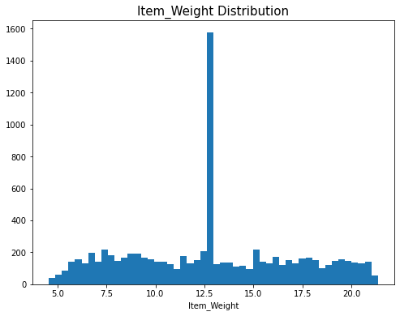

```python
N = 8523
bins = 50
x = df1['Item_Weight'].values

plt.figure(figsize=(8, 6))
plt.hist(x, bins = bins)
plt.xlabel('Item_Weight')
plt.title('Item_Weight Distribution', fontsize = 15)
plt.show()
```

```python
df1['Outlet_Size'].value_counts().index[0]
```

```
'Medium'
```

```python
df1['Outlet_Size'].fillna(df1['Outlet_Size'].value_counts().index[0], inplace=True)
df1.head()
```

|  | Item_Identifier | Item_Weight | Item_Fat_Content | Item_Visibility | Item_Type | Item_MRP | Outlet_Identifier | Outlet_Establishment_Year | Outlet_Size | Outlet_Location_Type | Outlet_Type | Item_Outlet_Sales |
| --- | --- | --- | --- | --- | --- | --- | --- | --- | --- | --- | --- | --- |
| 0 | FDA15 | 9.30 | Low Fat | 0.016047 | Dairy | 249.8092 | OUT049 | 1999 | Medium | Tier 1 | Supermarket Type1 | 3735.1380 |
| 1 | DRC01 | 5.92 | Regular | 0.019278 | Soft Drinks | 48.2692 | OUT018 | 2009 | Medium | Tier 3 | Supermarket Type2 | 443.4228 |
| 2 | FDN15 | 17.50 | Low Fat | 0.016760 | Meat | 141.6180 | OUT049 | 1999 | Medium | Tier 1 | Supermarket Type1 | 2097.2700 |
| 3 | FDX07 | 19.20 | Regular | 0.000000 | Fruits and Vegetables | 182.0950 | OUT010 | 1998 | Medium | Tier 3 | Grocery Store | 732.3800 |
| 4 | NCD19 | 8.93 | Low Fat | 0.000000 | Household | 53.8614 | OUT013 | 1987 | High | Tier 3 | Supermarket Type1 | 994.7052 |

Item_Fat_content의 명칭 통일

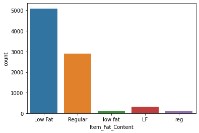

```python
sns.countplot(x = 'Item_Fat_Content', data = df1)
plt.show()
```

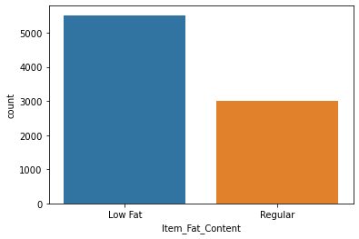

```python
mask1 = df1['Item_Fat_Content'].isin(['low fat', 'LF'])
mask2 = df1['Item_Fat_Content'].isin(['reg'])

df1.loc[mask1, 'Item_Fat_Content'] = 'Low Fat'
df1.loc[mask2, 'Item_Fat_Content'] = 'Regular'

sns.countplot(x = 'Item_Fat_Content', data = df1)
plt.show()
```

- 레이블 인코딩 수행

```python
from sklearn.preprocessing import LabelEncoder

le = LabelEncoder()

for column in [df1.columns[0], df1.columns[2], df1.columns[4], df1.columns[6], df1.columns[8], df1.columns[9], df1.columns[10]]:
    df1[column] = le.fit_transform(df1[column])

df1.head()
```

|  | Item_Identifier | Item_Weight | Item_Fat_Content | Item_Visibility | Item_Type | Item_MRP | Outlet_Identifier | Outlet_Establishment_Year | Outlet_Size | Outlet_Location_Type | Outlet_Type | Item_Outlet_Sales |
| --- | --- | --- | --- | --- | --- | --- | --- | --- | --- | --- | --- | --- |
| 0 | 156 | 9.30 | 0 | 0.016047 | 4 | 249.8092 | 9 | 1999 | 1 | 0 | 1 | 3735.1380 |
| 1 | 8 | 5.92 | 1 | 0.019278 | 14 | 48.2692 | 3 | 2009 | 1 | 2 | 2 | 443.4228 |
| 2 | 662 | 17.50 | 0 | 0.016760 | 10 | 141.6180 | 9 | 1999 | 1 | 0 | 1 | 2097.2700 |
| 3 | 1121 | 19.20 | 1 | 0.000000 | 6 | 182.0950 | 0 | 1998 | 1 | 2 | 0 | 732.3800 |
| 4 | 1297 | 8.93 | 0 | 0.000000 | 9 | 53.8614 | 1 | 1987 | 0 | 2 | 1 | 994.7052 |

- heatmap 통한 상관관계 분석

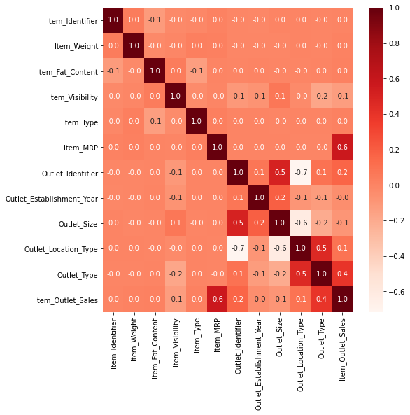

```python
plt.figure(figsize=(8, 8))
sns.heatmap(df1.corr(), cmap = 'Reds', annot = True, fmt = '.1f')
plt.show()
```

### 3. 훈련/테스트 데이터셋 분리

```python
X = df1.iloc[:, :-1]
y = df1.iloc[:, -1]
```

```python
from sklearn.model_selection import train_test_split

X_train, X_test, y_train, y_test = train_test_split(
    X, y, test_size=0.1, random_state= 2022
)
```

### 4 데이터 학습/훈련/평가

a) 선형회귀를 이용

```python
from sklearn.linear_model import LinearRegression

lr1 = LinearRegression()
lr1.fit(X_train, y_train)
pred_lr1 = lr1.predict(X_test)
lr1.score(X_test, y_test)
```

```
0.5158532885232525
```

```python
from sklearn.metrics import mean_squared_error

mse_lr1 = mean_squared_error(y_test, pred_lr1)
mse_lr1
```

```
1401992.6274881999
```

b) Random Forest를 이용

```python
from sklearn.ensemble import RandomForestRegressor

rfr1 = RandomForestRegressor(random_state= 2022)
rfr1.fit(X_train, y_train)
pred_rf1 = rfr1.predict(X_test)
mse_rf1 = mean_squared_error(y_test, pred_rf1)

rfr1.score(X_test, y_test), mse_rf1
```

```
(0.5547048822366247, 1289486.1358378255)
```

c) XGBoost를 이용

```python
from xgboost import XGBRegressor

xgb1 = XGBRegressor(random_state= 2022)
xgb1.fit(X_train, y_train)
pred_xg1 = xgb1.predict(X_test)
mse_xg1 = mean_squared_error(y_test, pred_xg1)

xgb1.score(X_test, y_test), mse_xg1
```

```
(0.5112677498686373, 1415271.435821366)
```

### 5 모델간 성과 비교

```python
df_score = pd.DataFrame({
    'y_test' : y_test, 'pred_lr' : pred_lr1, 'pred_rf' : pred_rf1, 'pred_xg' : pred_xg1
})
df_score.head(50)
```

|  | y_test | pred_lr | pred_rf | pred_xg |
| --- | --- | --- | --- | --- |
| 4714 | 2508.7344 | 3619.578845 | 4050.627330 | 4252.109863 |
| 1137 | 1966.7732 | 1801.033983 | 2203.944476 | 1886.396118 |
| 2590 | 842.2370 | 1095.467436 | 464.368868 | 440.000000 |
| 7387 | 657.8104 | 1347.604941 | 306.747376 | 92.653198 |
| 1822 | 1404.8380 | 2152.765630 | 2073.600810 | 1863.689453 |
| 8264 | 3705.1770 | 2414.893880 | 3894.011196 | 3337.900635 |
| 3877 | 1777.6860 | 2392.860081 | 1779.963036 | 1621.725220 |
| 2738 | 1861.5768 | 2171.216424 | 2736.797532 | 2372.581787 |
| 6734 | 539.2980 | 525.814637 | 1796.787802 | 959.690002 |
| 5194 | 3946.8624 | 4045.315453 | 3959.599154 | 4004.578125 |
| 1185 | 822.2630 | 1372.758975 | 420.472674 | 137.017776 |
| 6431 | 852.2240 | 1913.546155 | 1817.627342 | 1688.960449 |
| 8491 | 4809.7392 | 4081.037930 | 2969.454684 | 2747.673340 |
| 2140 | 661.8052 | 508.782567 | 894.648776 | 744.156433 |
| 7396 | 258.9962 | 2566.919445 | 703.877102 | 1259.810791 |
| 5676 | 4436.8912 | 2861.158958 | 2185.168916 | 2575.671875 |
| 2925 | 431.4384 | 3814.927930 | 3024.995720 | 2785.099609 |
| 5922 | 3048.6982 | 2783.677611 | 2660.982886 | 2520.056885 |
| 2059 | 1826.9552 | 3528.857934 | 4022.144406 | 4132.712891 |
| 1738 | 468.7232 | 678.890115 | 636.012108 | 658.128174 |
| 5857 | 3515.4240 | 2857.732915 | 2583.996432 | 2271.567871 |
| 7514 | 3570.0196 | 3503.315728 | 4203.468378 | 4059.540771 |
| 6166 | 406.1380 | 503.242881 | 506.753696 | 482.592316 |
| 4351 | 2482.1024 | 2490.168729 | 2126.065850 | 1731.252686 |
| 3760 | 1324.2762 | 2868.205630 | 2809.256546 | 2488.526611 |
| 1191 | 3717.8272 | 3682.667739 | 3231.193980 | 3041.916992 |
| 818 | 322.2472 | 1061.559710 | 1046.411228 | 1205.001099 |
| 2194 | 2579.9750 | 1688.869096 | 1687.343598 | 1542.042603 |
| 86 | 2716.4640 | 2174.046011 | 2507.003320 | 3084.060791 |
| 3136 | 3858.9768 | 2771.488647 | 3524.578750 | 3595.557617 |
| 5885 | 2993.4368 | 2762.916133 | 3211.246612 | 3204.647461 |
| 2928 | 3174.5344 | 3071.459512 | 3170.026934 | 2590.334473 |
| 5248 | 3709.8376 | 3999.713189 | 4044.621814 | 3943.487549 |
| 7600 | 937.4464 | 894.397335 | 863.189726 | 785.474060 |
| 4940 | 229.0352 | -682.807331 | 155.617434 | 482.120331 |
| 424 | 6687.9610 | 3325.202111 | 3082.101386 | 3604.725098 |
| 104 | 3185.8530 | 3779.434426 | 3194.541690 | 2949.955811 |
| 4014 | 2269.0464 | 2161.075753 | 3134.972564 | 2147.388184 |
| 351 | 5494.8474 | 4135.990789 | 4021.172338 | 4343.656738 |
| 1247 | 829.5868 | 995.452364 | 761.821676 | 1016.814636 |
| 826 | 5182.5872 | 3350.293270 | 3256.600908 | 2830.601074 |
| 1498 | 4394.2800 | 3386.793919 | 2570.001316 | 2946.911865 |
| 3544 | 4414.9198 | 3361.064292 | 4653.582468 | 3902.506104 |
| 7046 | 3715.1640 | 1599.938605 | 1893.228932 | 2004.715454 |
| 6465 | 2659.8710 | 2033.158850 | 2174.596012 | 2167.903564 |
| 7415 | 4390.2852 | 3123.753619 | 3238.011772 | 3109.690674 |
| 6371 | 2217.1140 | 3978.433405 | 2389.236616 | 3465.264160 |
| 3511 | 85.8882 | 17.789908 | 224.055016 | 93.844276 |
| 1167 | 1737.7380 | 1177.018730 | 1595.083692 | 1624.759644 |
| 6893 | 1845.5976 | 3909.971350 | 5186.535394 | 6057.507324 |

```python
print('Item_Weight, Outlet_Size의 결측치를 이전값으로 처리할 경우')
print(f'선형회귀 score :{lr.score(X_test, y_test)}, Random Forest score : {rfr.score(X_test, y_test)}, XGBoost score : {xgb.score(X_test, y_test)}')
print(f'선형회귀 mse :{mse_lr}, Random Forest mse : {mse_rf}, XGBoost mse : {mse_xg}')
print('')

print('Item_Weight의 결측치를 평균으로, Outlet_Size의 결측치를 최빈값으로 처리할 경우')
print(f'선형회귀 score :{lr1.score(X_test, y_test)}, Random Forest score : {rfr1.score(X_test, y_test)}, XGBoost score : {xgb1.score(X_test, y_test)}')
print(f'선형회귀 mse :{mse_lr1}, Random Forest mse : {mse_rf1}, XGBoost mse : {mse_xg1}')
```

```
Item_Weight, Outlet_Size의 결측치를 이전값으로 처리할 경우
선형회귀 score :0.5150392695173784, Random Forest score : 0.560314922208015, XGBoost score : 0.4965278771168786
선형회귀 mse :1409728.7494892639, Random Forest mse : 1290893.1020738774, XGBoost mse : 1478281.8621487399

Item_Weight의 결측치를 평균으로, Outlet_Size의 결측치를 최빈값으로 처리할 경우
선형회귀 score :0.5158532885232525, Random Forest score : 0.5547048822366247, XGBoost score : 0.5112677498686373
선형회귀 mse :1401992.6274881999, Random Forest mse : 1289486.1358378255, XGBoost mse : 1415271.435821366
```

### 결론) 결측치를 어떻게 처리하는지는 큰 영향이 없는 것으로 보인다